# TCVD Práctica 2: ¿Cómo realizar la limpieza y análisis de datos?

Alfonso Manuel Carvajal, Eider Ibiricu

16 de June, 2023

# Descripción del dataset

El dataset *Heart Attack Analysis & Prediction* [kaggle](https://www.kaggle.com/datasets/rashikrahmanpritom/heart-attack-analysis-prediction-dataset) contiene datos para realizar una clasificación de pacientes que tengan riesgo de sufrir un ataque al corazón.

Mediante este juego de datos es posible entrenar algoritmos que permitan un diagnóstico para futuros posibles pacientes.

```r
#https://medium.com/mcd-unison/how-to-use-kaggle-api-to-download-datasets-in-r-312179c7a99c

library(readr)
library(kaggler)
kgl_auth(creds_file = 'kaggle.json')
```

```
## <request>
## Options:
## * httpauth: 1
## * userpwd: eideribiricupera:2323ed93bf13610b7984e10597bedc72
```

```r
response <- kgl_datasets_download_all(owner_dataset =
            "rashikrahmanpritom/heart-attack-analysis-prediction-dataset")

download.file(response[["url"]], "data/temp.zip", mode="wb")
unzip_result <- unzip("data/temp.zip", exdir = "data/", overwrite = TRUE)
unzip_result
```

```
## [1] "data//heart.csv"        "data//o2Saturation.csv"
```

```r
heart_attack_data <- read_csv("data/heart.csv")
o2_saturation_data <- read.csv("data/o2Saturation.csv",header=F)

rm(response)
```

Las variables que encontramos en el dataset, según la descripción en *kaggle*:

- **Age**: Edad del individuo. (Variable numérica continua)
- **Sex**: Género del individuo (1 = masculino, 0 = femenino). (Variable categórica binaria)
- **cp**: Tipo de dolor en el pecho (categorica ordinal)
  - Value 1: typical angina
  - Value 2: atypical angina
  - Value 3: non-anginal pain
  - Value 4: asymptomatic
- **trtbps**: Presión arterial en reposo (en mm Hg) (Variable numérica continua)
- **chol**: Colesterol en mg/dl obtenido via sensor BMI (Variable numérica continua)
- **fbs**: Nivel de azúcar en sangre en ayunas (> 120 mg/dl, 1 = verdadero; 0 = falso). (Variable categórica binaria)
- **restecg**: Resultados electrocardiográficos en reposo. (Variable categórica ordinal)
  - Value 0: normal
  - Value 1: having ST-T wave abnormality (T wave inversions and/or ST elevation or depression of > 0.05 mV)
  - Value 2: showing probable or definite left ventricular hypertrophy by Estes’ criteria
- **thalachh**: Máxima frecuencia cardíaca alcanzada. (Variable numérica continua)
- **exng**: Angina inducida por ejercicio (1 = sí; 0 = no). (Variable categórica binaria)
- **oldpeak**: Pico anterior, cambios en el segmento ST en un ECG (Variable numérica continua)
- **slp**: La pendiente del segmento ST en el pico de ejercicio (Variable numérica continua)
- **caa**: Número de vasos principales coloreados por fluoroscopia. (0-4) (categorical)
- **thall**: Talio en sangre.(Thallium Stress Test )(numerica)
- **output**: Diagnóstico de enfermedad cardíaca (estado del objetivo) (0 = menos probabilidad de ataque al corazón, 1 = más probabilidad de ataque al corazón). (Variable categórica binaria)

¿Por qué es importante y qué pregunta/problema pretende responder?

# Integración y selección de los datos de interés a analizar.

Puede ser el resultado de adicionar diferentes datasets o una subselección útil de los datos originales, en base al objetivo que se quiera conseguir.

La recopilación y elección de información constituyen etapas fundamentales en cualquier tarea de análisis de datos. En relación a nuestro conjunto de información, estos procesos significarán identificar los factores que resultan más significativos para estimar un infarto al miocardio y optar por aquellos que nos brinden la mayor utilidad en nuestra investigación.

Dado que todas las variables en este conjunto de datos están directamente vinculadas a la salud cardiovascular y los riesgos asociados, todas podrían considerarse pertinentes. No obstante, puede que no todas estas variables contribuyan de la misma manera a la capacidad predictiva de un modelo de estimación de infartos al miocardio.

Por ejemplo, las variables `age`, `sex`, `cp`, `trtbps`, `chol`, `fbs`, `restecg`, `thalachh`, `exng`, `oldpeak`, `slp`, `caa`, y `thall` son todos posibles factores de riesgo para un infarto al miocardio y por lo tanto son de importancia para nuestro estudio. La variable `output` es la que nos gustaría pronosticar.

En consecuencia, el paso inicial en nuestro estudio será llevar a cabo un examen exploratorio de los datos para comprender de mejor manera la distribución y las relaciones de estas variables. Esto puede implicar visualizar la distribución de la información, calcular estadísticas descriptivas y analizar las correlaciones entre las diversas variables.

```r
head(heart_attack_data) %>%
  kable_setup %>%
  kable_paper(full_width = F)%>%
  column_spec(c(3,7,14), width = "2 cm") %>%
  column_spec(c(1,5,9,12,13), width = "0.8 cm") %>%
  row_spec(0,bold=TRUE)
```

[output not shown]

# Limpieza de los datos

Primero asignamos los tipos de datos a cada variable. En los **[comentarios](https://www.kaggle.com/datasets/rashikrahmanpritom/heart-attack-analysis-prediction-dataset/discussion/329925)** del dataset, hemos encontrado definiciones de los campos que nos ayudan a determinar el tipo de los datos:

```r
# Data types

data <- heart_attack_data %>%
  mutate(
    sex = factor(sex, levels=c(1,0),labels = c("male","female")),
    cp = factor(cp,
                levels=c(0,1,2,3),
                labels=c("typical angina","atypical angina","non-anginal pain","asymptomatic")),
    fbs = factor(fbs,levels=c(0,1),labels = c(F,T)),
    restecg = factor(restecg,levels = c(0,1,2),
                     labels = c("normal","ST-T wave abnormality","left ventricular hypertrophy")),
    exng = factor(exng),
    slp = factor(slp,levels = c(0,1,2),
                 labels = c("unsloping","flat","downsloping")),
    caa = factor(caa),
    thall = factor(thall,
                   levels = c(1,2,3),
                   labels = c("fixed defect","normal","reversable defect")),
    output = factor(output,levels=c(0,1),
                    labels = c("less chance of heart attack","more chance of heart attack"))
  )
```

Hacemos un resumen de los datos para identificar posibles valores nulos o atípicos. Esta tabla también nos permite entender los rangos en los que se mueven las variables.

También revisaremos si hay registros repetidos.

```r
# Summary
summary(data)
```

```
##       age            sex                     cp          trtbps
##  Min.   :29.00   male  :207   typical angina  :143   Min.   : 94.0
##  1st Qu.:47.50   female: 96   atypical angina : 50   1st Qu.:120.0
##  Median :55.00                non-anginal pain: 87   Median :130.0
##  Mean   :54.37                asymptomatic    : 23   Mean   :131.6
##  3rd Qu.:61.00                                       3rd Qu.:140.0
##  Max.   :77.00                                       Max.   :200.0
##       chol          fbs                              restecg       thalachh
##  Min.   :126.0   FALSE:258   normal                      :147   Min.   : 71.0
##  1st Qu.:211.0   TRUE : 45   ST-T wave abnormality       :152   1st Qu.:133.5
##  Median :240.0               left ventricular hypertrophy:  4   Median :153.0
##  Mean   :246.3                                                  Mean   :149.6
##  3rd Qu.:274.5                                                  3rd Qu.:166.0
##  Max.   :564.0                                                  Max.   :202.0
##  exng       oldpeak              slp      caa                   thall
##  0:204   Min.   :0.00   unsloping  : 21   0:175   fixed defect     : 18
##  1: 99   1st Qu.:0.00   flat       :140   1: 65   normal           :166
##          Median :0.80   downsloping:142   2: 38   reversable defect:117
##          Mean   :1.04                     3: 20   NA's             :  2
##          3rd Qu.:1.60                     4:  5
##          Max.   :6.20
##                          output
##  less chance of heart attack:138
##  more chance of heart attack:165
##
##
##
##
```

```r
# Duplicates
data %>%
  unique() %>%
  nrow()
```

```
## [1] 302
```

```r
data <- data %>%
  unique()
```

## ¿Los datos contienen ceros o elementos vacíos?

Representamos las distribuciones de las variables:

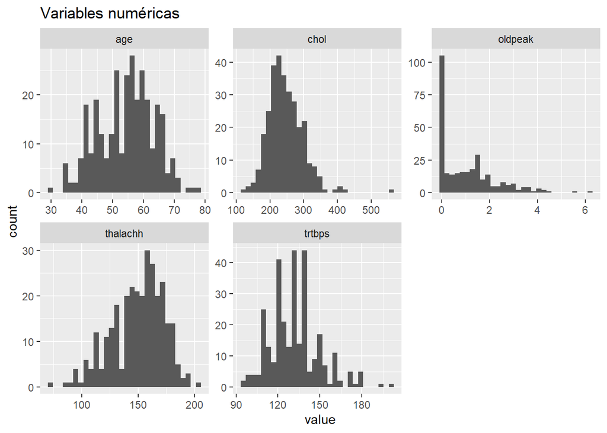

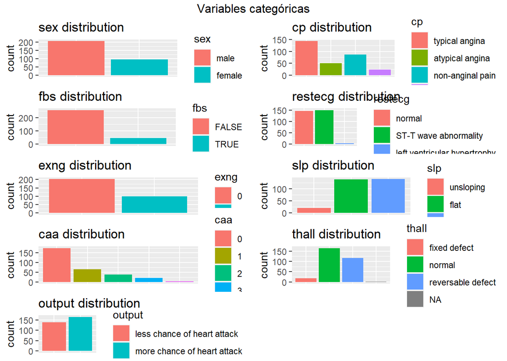

Vemos que la variable *thall* tiene valores nulos. Podemos considerar que estos registros como normales, por lo que les asignaremos el valor 2:

```r
data <- data %>%
  mutate(
    thall = factor(if_else(is.na(as.numeric(thall)),2,as.numeric(thall)),
                   levels = c(1,2,3),
                   labels = c("fixed defect","normal","reversable defect"))
  )
```

## Identifica y gestiona los valores extremos.

Estudiaremos los boxplots de las variables numéricas para observar si existen valores atípicos:

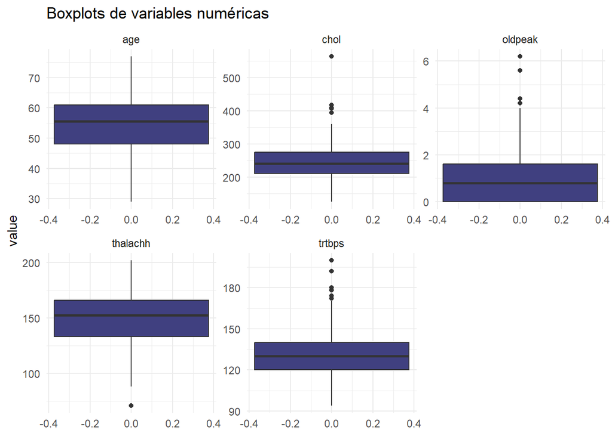

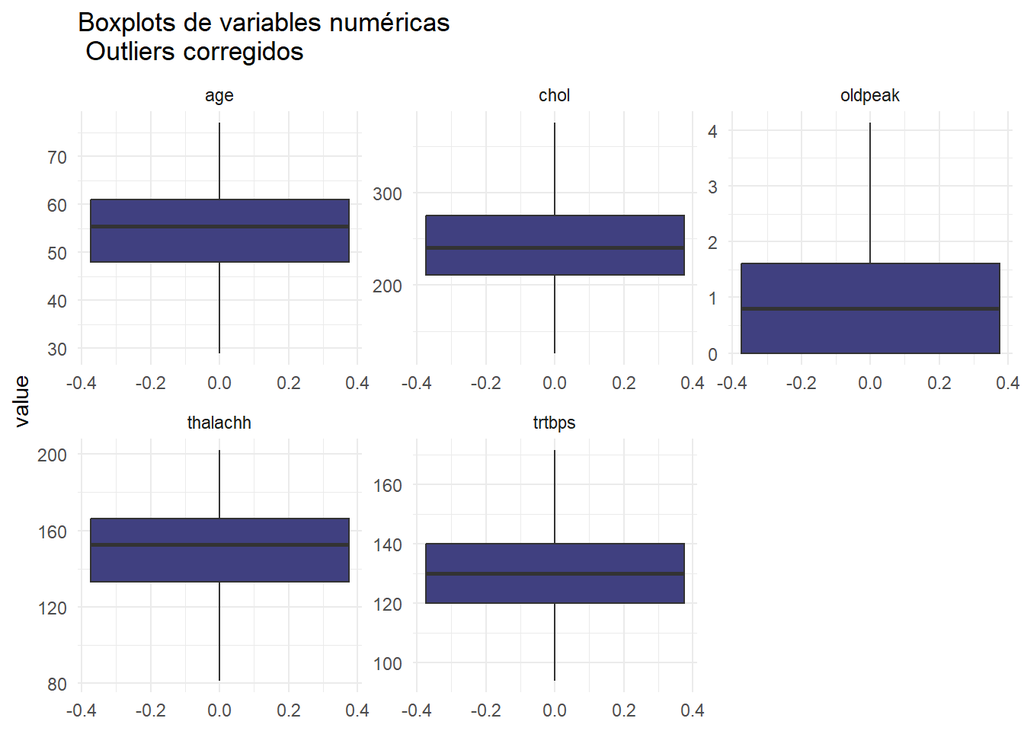

```r
for (col in colnames(data_num)){
  value = data[[col]][data[[col]] %in% boxplot.stats(data[[col]])$out]
  res <- quantile(data[[col]], probs = c(0,0.25,0.5,0.75,1))
  q1 <- res[[2]]
  q3 <- res[[4]]
  iqr <- q3 - q1
  min_thshld <- q1 - 1.58*iqr
  max_thshld <- q3 + 1.58*iqr
  data[[col]][data[[col]] < min_thshld] = min_thshld
  data[[col]][data[[col]] > max_thshld] = max_thshld
}


data %>%
  select_if(is.numeric) %>%
pivot_longer(colnames(data_num)) %>%
  as.data.frame() %>%
  ggplot(aes(y = value)) +    # Draw each column as histogram
  geom_boxplot(fill = "#404080", coef = 1.58) +
  theme_minimal() +
  facet_wrap(~ name, scales = "free") +
  labs(title="Boxplots de variables numéricas \n Outliers corregidos")
```

# Análisis de los datos

## Selección de los grupos de datos que se quieren analizar/comparar.

Lo primero que haremos será estudiar la correlación entre las variables y también la que tienen con la variable *output*.

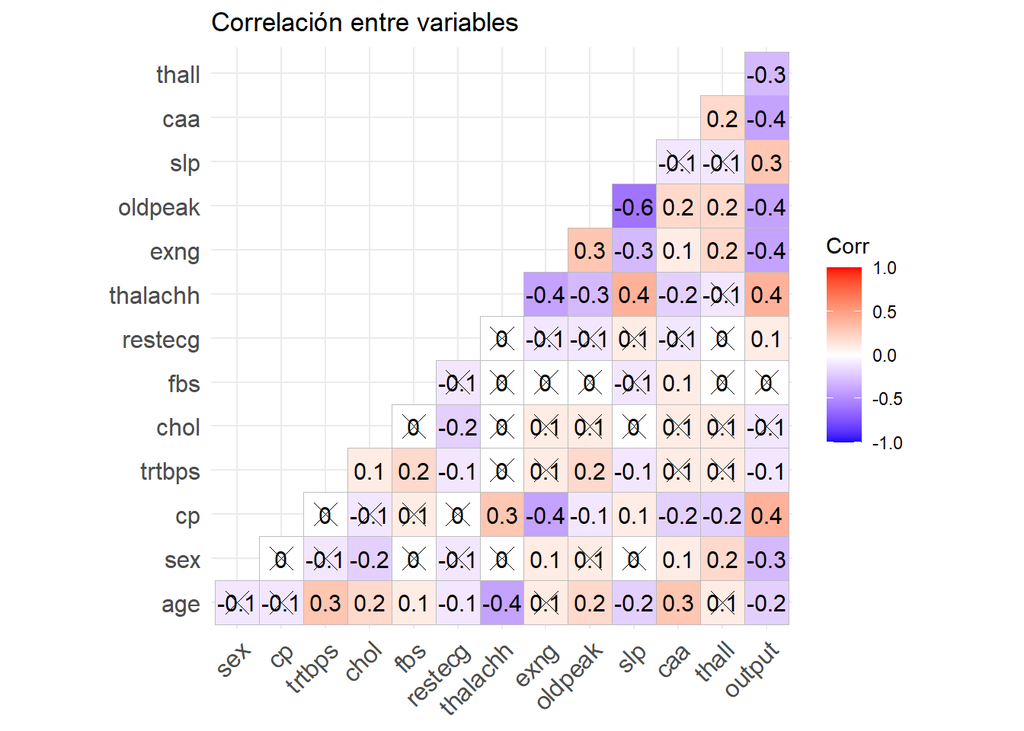

Respecto al resto de variables, vemos parejas relacionadas como *oldpeak* y *slp*, *cp* y *exng*, *age* y *thallachh*, *thallachh* y *slp*.

## Comprobación de la normalidad y homogeneidad de la varianza.

Vamos a analizar las variables recién mencionadas, para determinar si son aptas para aplicar tests de comparación de grupos.

```r
data_compare <- data %>%
  select(
    age,
    cp,
    fbs,
    thalachh,
    exng,
    oldpeak,
    slp,
    caa,
    output
  )
head(data_compare)
```

| age | cp | fbs | thalachh | exng | oldpeak | slp | caa | output |
| --- | --- | --- | --- | --- | --- | --- | --- | --- |
| 63 | asymptomatic | TRUE | 150 | 0 | 2.3 | unsloping | 0 | more chance of heart attack |
| 37 | non-anginal pain | FALSE | 187 | 0 | 3.5 | unsloping | 0 | more chance of heart attack |
| 41 | atypical angina | FALSE | 172 | 0 | 1.4 | downsloping | 0 | more chance of heart attack |
| 56 | atypical angina | FALSE | 178 | 0 | 0.8 | downsloping | 0 | more chance of heart attack |
| 57 | typical angina | FALSE | 163 | 1 | 0.6 | downsloping | 0 | more chance of heart attack |
| 57 | typical angina | FALSE | 148 | 0 | 0.4 | flat | 0 | more chance of heart attack |

### Normalidad

Vamos a analizar si las variables numéricas tienen distribuciones normales. Para ello aplicamos el test *Shapiro-Wilk*:

```
##
##  Shapiro-Wilk normality test
##
## data:  data_compare$oldpeak
## W = 0.85269, p-value = 2.615e-16
```

```
##
##  Shapiro-Wilk normality test
##
## data:  data_compare$thalachh
## W = 0.97705, p-value = 9.187e-05
```

```
##
##  Shapiro-Wilk normality test
##
## data:  data_compare$age
## W = 0.98664, p-value = 0.006745
```

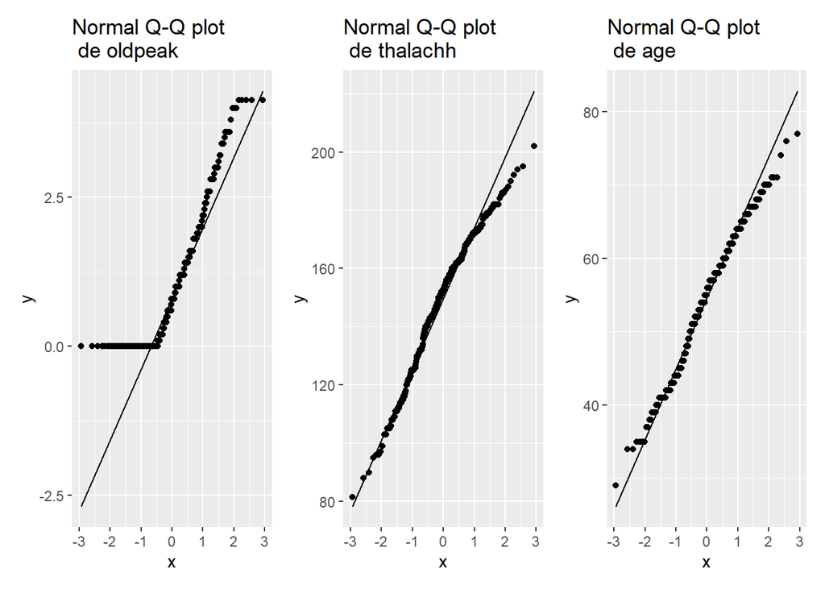

El test Shapiro-Wilk parte de la hipótesis de que la población está normalmente distribuida, por lo que si el resultado del p-valor es mayor que 0.05, podemos aceptar dicha hipótesis con un 95% de confianza.

En el caso anterior, vemos que no se puede aceptar que tanto *oldpeak* como *thalachh* estén normalmente distribuidas.

Podemos visualizar que las medias por los dos grupos objetivo no son iguales:

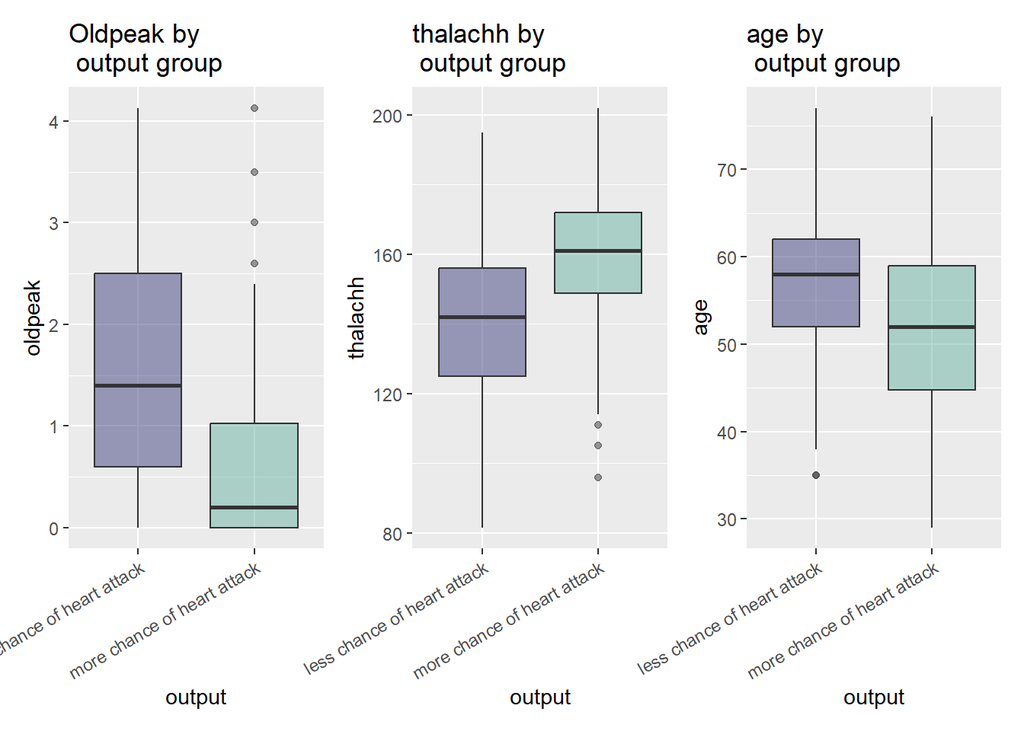